# HW 4 Solution

### Question 3

We will use the `USArrests` data set that is inbuilt in R.

Recreate the following plot in R

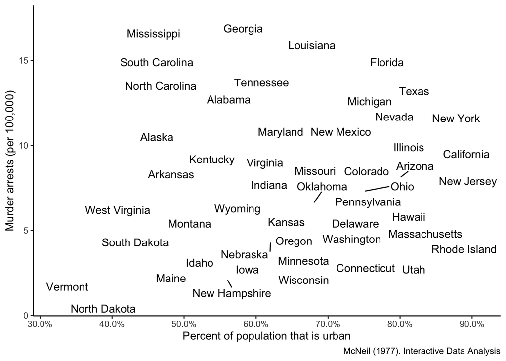

```r
library(ggrepel)
USArrests %>%
  rownames_to_column("State") %>%
  ggplot(aes(UrbanPop / 100, Murder)) +
  geom_text_repel(aes(label = State)) +
  labs(
    y = "Murder arrests (per 100,000)",
    caption = "McNeil (1977). Interactive Data Analysis"
  ) +
  scale_x_continuous("Percent of population that is urban",
    labels = scales::percent
  ) +
  theme_classic()
```

> You will need to add the rownames in the data to become a proper column named `State` using `USArrests %>% rownames_to_column('State')`

### Question 4

Using the `riskfactors` data, create a panel of plots using any of the three packages introduced in lecture, where the plots will be

1. A histogram of age
2. A frequency bar plot of sex
3. A boxplot of BMI by education level
4. A barplot showing the proportion of each educational level for each marital status.

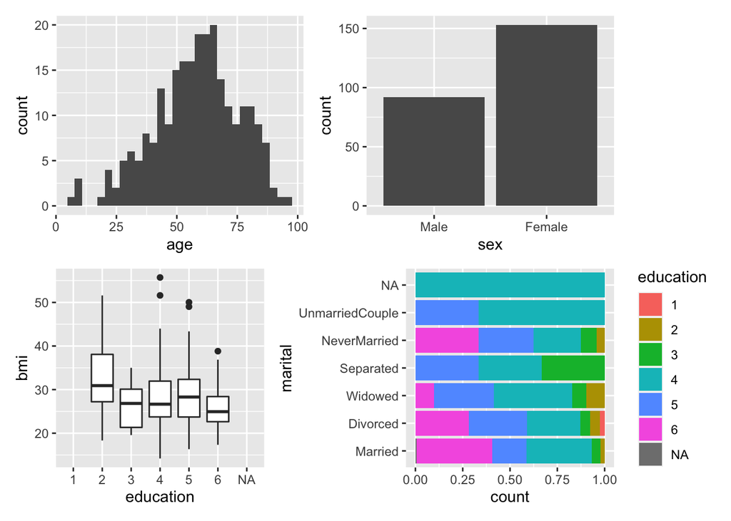

```r
library(ggplot2)
library(cowplot)
library(ggpubr)
library(patchwork)

plt1 <- ggplot(riskfactors) +
  geom_histogram(aes(x = age))
plt2 <- ggplot(riskfactors) +
  geom_bar(aes(x = sex))
plt3 <- ggplot(riskfactors) +
  geom_boxplot(aes(x = education, y = bmi))
plt4 <- ggplot(riskfactors) +
  geom_bar(aes(x = marital, fill = education), position = "fill") +
  coord_flip()

# plot_grid(plt1, plt2, plt3, plt4, nrow=2)

# ggarrange(plt1, plt2, plt3, plt4, nrow=2, ncol=2)

(plt1 + plt2) / (plt3 + plt4)
```

### Extra credit (10 pts)

Install the **coronavirus** package (`install.packages('coronavirus')`). Once that is installed, run `coronavirus::update_dataset()`. This will update the data to the latest data from JHU, and also ask you to restart your R session (`Session > Restart R`).

#### Part a

The `coronavirus` dataset is in the **coronavirus** package and contains data on cases, deaths and recoveries on a daily basis from around the world. We will only use the deaths data, which is obtained by filtering the rows of the `coronavirus` dataset to contain only rows with `type=="death"`

Extract out data for 15 February, 2021 (`date == "2021-02-15"`) and then identify the top 10 countries in terms of deaths on that date.

There are a couple of nuances here. For some countries, there is also provincial data, so you have to sum over those rows within country (`%>% group_by(country) %>% summarise(cases = sum(cases, na.rm=T) %>% ungroup()`))

You can use `slice_max` to grab the approriate rows. To pull out the countries, you can then use `%>% pull(country)` and save the result. You should have

```r
library(coronavirus)
date_choice <- "2021-02-15"
coronavirus %>%
  filter(date == date_choice, type == "death") %>%
  group_by(country) %>%
  summarise(cases = sum(cases, na.rm = T)) %>%
  ungroup() %>%
  slice_max(cases, n = 10) %>%
  pull(country)
```

```
##  [1] "US"             "Spain"          "Brazil"         "Mexico"
##  [5] "France"         "Russia"         "Italy"          "United Kingdom"
##  [9] "South Africa"   "Indonesia"
```

#### Part b

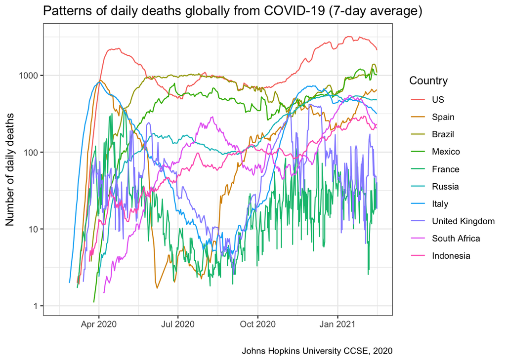

```r
library(coronavirus)
library(tidyquant)
date_choice <- "2021-02-15"
coronavirus %>%
  filter(date == date_choice, type == "death") %>%
  group_by(country) %>%
  summarise(cases = sum(cases, na.rm = T)) %>%
  ungroup() %>%
  slice_max(cases, n = 10) %>%
  pull(country) -> country_top10

coronavirus %>%
  filter(type == "death", country %in% country_top10,
         date <= date_choice) %>%
  ggplot(aes(
    x = date, y = cases,
    color = fct_reorder2(country, date, cases)
  )) +
  # geom_smooth(se=FALSE) +
  geom_ma(n = 7, linetype = 1) +
  scale_y_log10("Number of daily deaths") +
  labs(
    x = "", color = "Country",
    title = "Patterns of daily deaths globally from COVID-19 (7-day average)",
    caption = "Johns Hopkins University CCSE, 2020"
  ) +
  theme_bw()
```